# Module 5. Modelling covariance and choosing a model

Slides

# Why the covariance matters

## The estimand is a within-person change, so correlation changes the standard error

EP minus UC, difference in mean change to month 12 (mmHg)

|  | estimate | SE |
| --- | --- | --- |
| Independence | -9.11 | 2.57 |
| Compound symmetry | -8.99 | 1.22 |

- Same mean model, two assumptions about correlation.
- Estimates almost equal; standard errors differ by a factor of 2.1.

## Four reasons to care about the covariance model

1. Standard errors of within-person contrasts depend on it.
2. Under MAR dropout, the estimated means depend on it.
3. A covariance that is too simple can make SEs **too small**.
4. Sometimes the covariance is the question (stability, measurement error).

## Look at the data first: residual correlations are high and fall slowly with lag

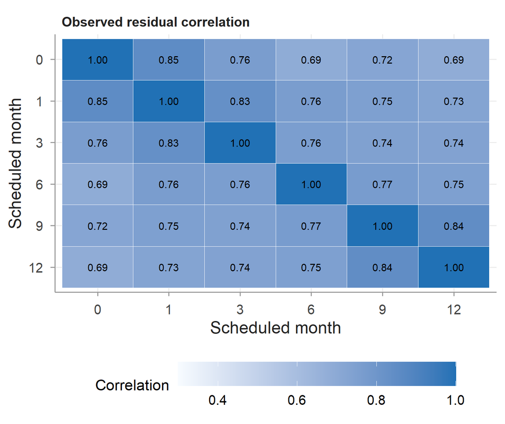

## Because the data are simulated, we know the recipe

| Component | SD (true) | Correlation pattern |
| --- | --- | --- |
| Random intercept | 11 mmHg | constant |
| Random slope | 0.35 mmHg/month | grows with time |
| Clinic | 3 mmHg | constant within clinic |
| Serial process | 5 mmHg | $\exp(-\lvert\Delta t\rvert/3)$ |
| Measurement error | 4 mmHg | none |

# Residual correlation structures

## A covariance structure is a rule for filling in a participant’s covariance matrix

$$\mathbf{y}_i = X_i\boldsymbol\beta + \boldsymbol\varepsilon_i, \quad \boldsymbol\varepsilon_i \sim N(\mathbf{0}, R_i), \quad R_i = \sigma^2 C_i$$

| Structure | $[C_i]_{jk}$ | Parameters (6 visits) |
| --- | --- | --- |
| Compound symmetry | $\rho$ | 1 |
| AR(1) by visit | $\rho^{\lvert j-k\rvert}$ | 1 |
| Exponential + nugget | $(1-c)\,e^{-\lvert t_{ij}-t_{ik}\rvert/\phi}$ | 2 |
| Unstructured | free $\sigma_{jk}$ | 21 |

## Fitting the structures with `gls()`

```r
m_cs  <- gls(sbp ~ visit_f * arm, data = walk,
             correlation = corCompSymm(form = ~ 1 | id))
m_ar1 <- gls(sbp ~ visit_f * arm, data = walk,
             correlation = corAR1(form = ~ visit | id))      # integer index
m_exp <- gls(sbp ~ visit_f * arm, data = walk,
             correlation = corExp(form = ~ month | id, nugget = TRUE))
m_un  <- gls(sbp ~ visit_f * arm, data = walk,
             correlation = corSymm(form = ~ visit | id),
             weights = varIdent(form = ~ 1 | visit_f))
```

## The exponential range is long because there is no random intercept

| range | nugget | cor_1_month | cor_12_months |
| --- | --- | --- | --- |
| 60.44 | 0.14 | 0.85 | 0.71 |

- A single exponential must keep correlations near 0.7 over a year.
- It does so with a range of about 60 months, absorbing the stable person component.

## Compare implied and observed correlations

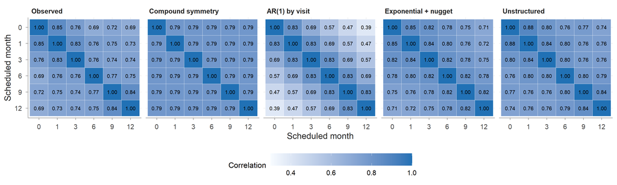

## Implied correlations come from a formula you can compute

```r
# Residual part: R = sigma^2 * S C S   (S = SD ratios from varIdent)
# Random-effects part (lme only): Z G Z'
V <- implied_cov(m_un)          # helper defined in the notes
round(cov2cor(V), 2)
```

```
#>       0    1    3    6    9   12
#> 0  1.00 0.88 0.80 0.76 0.77 0.74
#> 1  0.88 1.00 0.84 0.80 0.76 0.76
#> 3  0.80 0.84 1.00 0.80 0.76 0.76
#> 6  0.76 0.80 0.80 1.00 0.80 0.79
#> 9  0.77 0.76 0.76 0.80 1.00 0.84
#> 12 0.74 0.76 0.76 0.79 0.84 1.00
```

## Try it

Workbook exercise 1: fit CS, AR(1) and exponential structures, and compare their implied correlations with the observed matrix.

# Heterogeneous variances

## `varIdent()` lets the residual SD differ by visit

$$R_i = \sigma^2 S_i C_i S_i, \qquad S_i = \operatorname{diag}(\delta_{v(ij)}), \quad \delta_0 = 1$$

```r
coef(m_cs_het$modelStruct$varStruct, unconstrained = FALSE, allCoef = TRUE)
```

```
#>      0      1      3      6      9     12
#> 1.0000 0.9992 1.0090 1.0432 1.0317 1.0294
```

```r
anova(m_cs, m_cs_het)
```

```
#>          Model df   AIC   BIC logLik   Test L.Ratio p-value
#> m_cs         1 20 13353 13464  -6656
#> m_cs_het     2 25 13360 13499  -6655 1 vs 2   2.639  0.7555
```

# Random effects plus residual correlation

## The marginal covariance combines both sources

$$V_i = \operatorname{Var}(\mathbf{y}_i) = Z_i G Z_i^\top + R_i$$

$$\operatorname{Cov}(y_{it}, y_{is}) = \tau_0^2 + \tau_{01}(t+s) + \tau_1^2 ts + [R_i]_{ts}$$

- Random intercept only: constant covariance, i.e. compound symmetry.
- Random slope: variance is quadratic in time.
- Plus exponential residuals: correlation declines with lag, then levels off.

## `lme()` fits random effects and a correlation structure together

```r
m_rs_exp <- lme(sbp ~ visit_f * arm, random = ~ 1 + month | id,
                correlation = corExp(form = ~ month | id, nugget = TRUE),
                data = walk)
```

| parameter | estimate | truth |
| --- | --- | --- |
| SD intercept | 11.90 | 11 (+ clinic 3) |
| SD slope | 0.34 | 0.35 |
| Correlation | -0.10 | -0.25 |
| Residual SD | 6.27 | 6.4 |
| Range (months) | 1.63 | 3 |
| Nugget | 0.16 | 0.39 |

## Without serial correlation, the random slope absorbs it

| model | SD_slope |
| --- | --- |
| Random intercept + slope | 0.54 |
| … + exponential | 0.34 |

- True slope SD 0.35 mmHg/month.
- Components of a misspecified covariance model can absorb features they were not meant to describe.

## The combined model reproduces the observed pattern

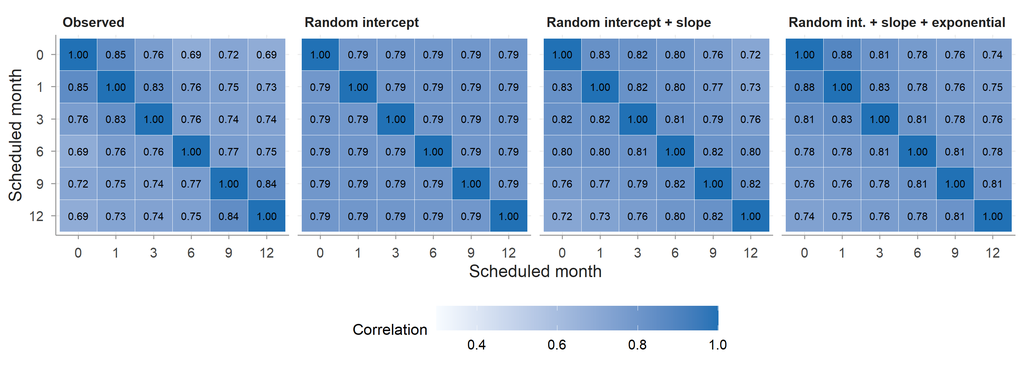

## The semivariogram checks serial correlation with irregular times

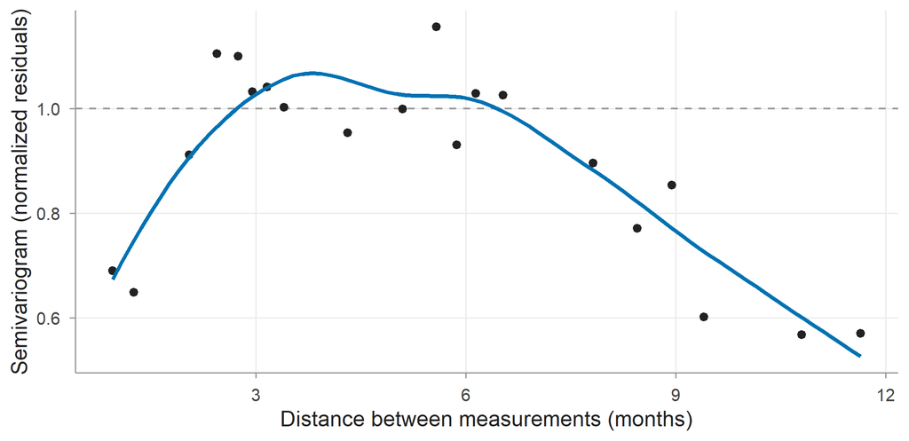

## Try it

Workbook exercise 2: compute $V_i = Z_iGZ_i^\top + R_i$ by hand for the random intercept and slope model and check it against `implied_cov()`.

# Comparing models

## REML for covariance, ML for fixed effects

- **REML** likelihoods depend on the fixed-effects design $X$.
- Compare covariance models only when the **fixed effects are identical**.
- Compare fixed effects with **ML**; refit the chosen model with REML.

| time_in | REML_logLik | ML_logLik |
| --- | --- | --- |
| months | -6710 | -6708 |
| weeks | -6714 | -6708 |

## AIC and BIC rank the candidate covariance models

| Model | Cov. pars | AIC | BIC | ΔAIC | ΔBIC |
| --- | --- | --- | --- | --- | --- |
| Independence | 1 | 15152 | 15257 | 1896.5 | 1879.9 |
| Compound symmetry | 2 | 13353 | 13464 | 97.8 | 86.8 |
| AR(1) by visit | 2 | 13454 | 13565 | 199.5 | 188.5 |
| Exponential + nugget | 3 | 13267 | 13383 | 12.2 | 6.7 |
| CS + heterogeneous variances | 7 | 13360 | 13499 | 105.2 | 121.8 |
| Unstructured | 21 | 13272 | 13488 | 17.0 | 111.2 |
| Random intercept | 2 | 13353 | 13464 | 97.8 | 86.8 |
| Random intercept + slope | 4 | 13292 | 13414 | 36.9 | 36.9 |
| Random intercept + exponential | 4 | 13255 | 13377 | 0.0 | 0.0 |
| Random int. + slope + exponential | 6 | 13257 | 13390 | 1.6 | 12.7 |

## Likelihood-ratio tests need nesting

```r
anova(m_ri, m_ri_exp)
```

```
#>          Model df   AIC   BIC logLik   Test L.Ratio p-value
#> m_ri         1 20 13353 13464  -6656
#> m_ri_exp     2 22 13255 13377  -6605 1 vs 2   101.8  <.0001
```

```r
anova(m_cs, m_un)
```

```
#>      Model df   AIC   BIC logLik   Test L.Ratio p-value
#> m_cs     1 20 13353 13464  -6656
#> m_un     2 39 13272 13488  -6597 1 vs 2   118.8  <.0001
```

# Boundaries and singular fits

## Testing a variance of zero: the null is on the boundary

$$\text{LR} \ \dot\sim\ \tfrac12\chi^2_0 + \tfrac12\chi^2_1 \quad\Rightarrow\quad p = \tfrac12 P(\chi^2_1 > \text{LR})$$

- Random slope added to random intercept: $\tfrac12\chi^2_1 + \tfrac12\chi^2_2$ (Stram and Lee 1994).
- Naive $\chi^2$ p-values are conservative (Self and Liang 1987).

```r
m_clinic <- lmer(sbp ~ visit_f * arm + (1 + month | id) + (1 | clinic),
                 data = walk, control = lmer_ctrl)
lt <- lr_test(m_prim, m_clinic)
c(chisq = lt$chisq, naive_p = lt$p, mixture_p = p_boundary_mixture(lt$chisq))
```

```
#>     chisq   naive_p mixture_p
#> 1.068e+01 1.085e-03 5.426e-04
```

## A singular fit: random slopes for 8 clinics

```r
m_cs2 <- lmer(sbp ~ visit_f * arm + (1 + month | id) + (1 + month | clinic),
              data = walk, control = lmer_ctrl)
VarCorr(m_cs2)
```

```
#>  Groups   Name        Std.Dev. Corr
#>  id       (Intercept) 11.851
#>           month        0.524   -0.17
#>  clinic   (Intercept)  3.755
#>           month        0.139   -1.00
#>  Residual              5.622
```

```r
isSingular(m_cs2)
```

```
#> [1] TRUE
```

## Responding to singular fits and convergence warnings

- Find the component on the boundary: `VarCorr()`, `rePCA()`.
- Simplify: drop it, or remove the correlation.
- Check whether the estimand changes.
- Convergence warnings: rescale, simplify, compare optimisers (`allFit()`).

| model | contrast | estimate | SE |
| --- | --- | --- | --- |
| Primary | SP - UC | -5.38 | 1.42 |
| Primary | EP - UC | -8.97 | 1.44 |
| + clinic intercept | SP - UC | -5.35 | 1.42 |
| + clinic intercept | EP - UC | -8.94 | 1.44 |
| + clinic slope (singular) | SP - UC | -5.63 | 1.41 |
| + clinic slope (singular) | EP - UC | -9.06 | 1.42 |

## Try it

Workbook exercises 3 and 4: a boundary test for the clinic variance, and a singular fit in a small subset.

# Choosing a model

## The treatment estimate barely depends on the covariance model

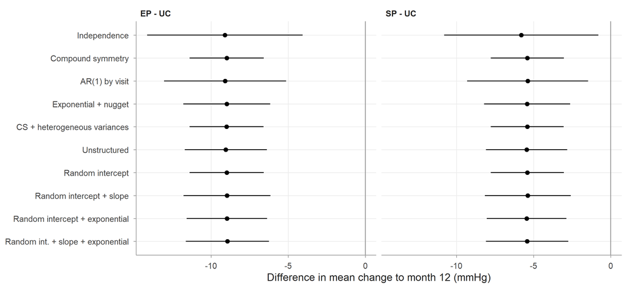

## Maximal or parsimonious?

- Barr et al. (2013): keep random-effects structures maximal for confirmatory tests, because omitting real slope variance can be anti-conservative.
- Matuschek et al. (2017): maximal models lose power and often fail to converge; data-supported parsimony keeps type I error near nominal.
- In a parallel-group trial: describe each participant’s covariance adequately, simplify when singular, check that the estimand is insensitive.

## Principles for choosing the covariance model

1. Prespecify a structure that can describe a stable person component and decline with lag.
2. Use AIC/BIC, heatmaps and semivariograms to check, not to search.
3. Report sensitivity analyses with alternative structures.
4. Keep the purpose in mind: treatment effect, individual prediction, or variance decomposition.

## Try it

Workbook independent exercises: choose and defend a covariance model for the WALK participants in clinics 1 to 4.

## Summary

- $V_i = Z_iGZ_i^\top + R_i$: random effects and residual correlation together.
- CS, AR(1), exponential (+ nugget), unstructured: different rules for correlation versus lag.
- REML for covariance comparisons with the same fixed effects; ML for fixed effects.
- Boundary tests need mixture p-values; singular fits signal an over-rich structure.
- The treatment estimate barely changes across sensible covariance models.

Barr, Dale J., Roger Levy, Christoph Scheepers, and Harry J. Tily. 2013. ‘Random Effects Structure for Confirmatory Hypothesis Testing: Keep It Maximal’. *Journal of Memory and Language* 68 (3): 255–78. https://doi.org/10.1016/j.jml.2012.11.001.

Matuschek, Hannes, Reinhold Kliegl, Shravan Vasishth, Harald Baayen, and Douglas Bates. 2017. ‘Balancing Type I Error and Power in Linear Mixed Models’. *Journal of Memory and Language* 94: 305–15. https://doi.org/10.1016/j.jml.2017.01.001.

Self, Steven G., and Kung-Yee Liang. 1987. ‘Asymptotic Properties of Maximum Likelihood Estimators and Likelihood Ratio Tests Under Nonstandard Conditions’. *Journal of the American Statistical Association* 82 (398): 605–10. https://doi.org/10.1080/01621459.1987.10478472.

Stram, Daniel O., and Jae Won Lee. 1994. ‘Variance Components Testing in the Longitudinal Mixed Effects Model’. *Biometrics* 50 (4): 1171–77. https://doi.org/10.2307/2533455.